# Test3

*Фунтикова Анастасия*

*316*

Подключим необходимые библиотеки

```r
library(MASS)
library(rriskDistributions)
library(nortest)
```

Импортируем данные и перейдем к логарифмическим доходностям.

```r
data <- read.csv('Stocks.csv')
rownames(data) = data$X
rates <- as.data.frame(apply(log(data[,2:ncol(data)]), 2, diff))
head(rates)
```

|  | AUDUSD | BZ | CHFUSD | EURUSD | GC | PL | SPX | USDNOK |
| --- | --- | --- | --- | --- | --- | --- | --- | --- |
| 250322 | 0.0002795918 | 0.014946957 | -0.0013303379 | -0.0023919649 | -0.0019902535 | -0.023877332 | 0.005053402 | -0.006441097 |
| 280322 | -0.0021455375 | -0.118241550 | -0.0029647331 | 0.0007645956 | -0.0168452148 | -0.019379089 | 0.007119560 | 0.011256331 |
| 290322 | 0.0023585074 | 0.018219504 | 0.0024805347 | 0.0091118041 | -0.0009875517 | -0.002842930 | 0.012182027 | -0.004572766 |
| 300322 | -0.0016783668 | 0.022227186 | 0.0084582787 | 0.0062019883 | 0.0033226071 | 0.010619569 | -0.006313610 | -0.010859957 |
| 310322 | -0.0013740939 | -0.049398457 | 0.0001477541 | -0.0078714001 | 0.0070755621 | -0.005953299 | -0.015776327 | 0.024250621 |
| 10422 | 0.0011074272 | -0.008555185 | -0.0025518237 | -0.0023056589 | -0.0075421372 | 0.002022041 | 0.003404486 | -0.004620644 |

## Определение значимости предикторов

Построим регрессионную модель и с помощью нее оценим значимость параметров.

```r
regr <-  lm(AUDUSD ~ BZ + CHFUSD + EURUSD + GC + PL + SPX + USDNOK, data=rates)
summary(regr)
```

```
Call:
lm(formula = AUDUSD ~ BZ + CHFUSD + EURUSD + GC + PL + SPX +
    USDNOK, data = rates)

Residuals:
       Min         1Q     Median         3Q        Max
-0.0154284 -0.0025996  0.0003075  0.0023284  0.0120594

Coefficients:
              Estimate Std. Error t value Pr(>|t|)
(Intercept) -0.0001939  0.0001877  -1.033  0.30232
BZ          -0.0263560  0.0095461  -2.761  0.00598 **
CHFUSD       0.1362038  0.0543747   2.505  0.01258 *
EURUSD       0.0867363  0.0634714   1.367  0.17241
GC           0.1163314  0.0263972   4.407 1.29e-05 ***
PL           0.0588202  0.0135669   4.336 1.77e-05 ***
SPX          0.1411388  0.0189266   7.457 4.15e-13 ***
USDNOK      -0.3839530  0.0362521 -10.591  < 2e-16 ***
---
Signif. codes:  0 ‘***’ 0.001 ‘**’ 0.01 ‘*’ 0.05 ‘.’ 0.1 ‘ ’ 1

Residual standard error: 0.004131 on 481 degrees of freedom
Multiple R-squared:  0.711, Adjusted R-squared:  0.7068
F-statistic:   169 on 7 and 481 DF,  p-value: < 2.2e-16
```

Константа и предиктор `EURUSD` явно лишние в модели.

Попытаемся понять, стоит ли исключать из модели предикторы `BZ` и `CHFUSD`, давшие слабый результат по сравнению с остальными. Для этого построим модели без них и посмотрим на их характеристики.

Для начала уберем только `EURUSD` и константу.

```r
regr <-  lm(AUDUSD ~ BZ + CHFUSD + GC + PL + SPX + USDNOK -1, data=rates)
summary(regr)
```

```
Call:
lm(formula = AUDUSD ~ BZ + CHFUSD + GC + PL + SPX + USDNOK -
    1, data = rates)

Residuals:
       Min         1Q     Median         3Q        Max
-0.0153310 -0.0026740  0.0001306  0.0021619  0.0116154

Coefficients:
        Estimate Std. Error t value Pr(>|t|)
BZ     -0.028486   0.009425  -3.023 0.002640 **
CHFUSD  0.171062   0.047072   3.634 0.000309 ***
GC      0.116379   0.026396   4.409 1.28e-05 ***
PL      0.061967   0.013417   4.619 4.96e-06 ***
SPX     0.141089   0.018901   7.465 3.92e-13 ***
USDNOK -0.409693   0.031974 -12.813  < 2e-16 ***
---
Signif. codes:  0 ‘***’ 0.001 ‘**’ 0.01 ‘*’ 0.05 ‘.’ 0.1 ‘ ’ 1

Residual standard error: 0.004135 on 483 degrees of freedom
Multiple R-squared:  0.7096,    Adjusted R-squared:  0.706
F-statistic: 196.7 on 6 and 483 DF,  p-value: < 2.2e-16
```

Теперь уберем и `BZ`.

```r
regr <-  lm(AUDUSD ~ CHFUSD + GC + PL + SPX + USDNOK - 1, data=rates)
summary(regr)
```

```
Call:
lm(formula = AUDUSD ~ CHFUSD + GC + PL + SPX + USDNOK - 1, data = rates)

Residuals:
       Min         1Q     Median         3Q        Max
-0.0158884 -0.0026785  0.0001691  0.0023294  0.0124390

Coefficients:
       Estimate Std. Error t value Pr(>|t|)
CHFUSD  0.19936    0.04652   4.286 2.20e-05 ***
GC      0.11570    0.02662   4.347 1.68e-05 ***
PL      0.05700    0.01343   4.245 2.62e-05 ***
SPX     0.14387    0.01904   7.558 2.07e-13 ***
USDNOK -0.37197    0.02968 -12.531  < 2e-16 ***
---
Signif. codes:  0 ‘***’ 0.001 ‘**’ 0.01 ‘*’ 0.05 ‘.’ 0.1 ‘ ’ 1

Residual standard error: 0.00417 on 484 degrees of freedom
Multiple R-squared:  0.7041,    Adjusted R-squared:  0.701
F-statistic: 230.3 on 5 and 484 DF,  p-value: < 2.2e-16
```

А теперь `BZ` и `CHFUSD`.

```r
regr <-  lm(AUDUSD ~ GC + PL + SPX + USDNOK - 1, data=rates)
summary(regr)
```

```
Call:
lm(formula = AUDUSD ~ GC + PL + SPX + USDNOK - 1, data = rates)

Residuals:
       Min         1Q     Median         3Q        Max
-0.0147149 -0.0027796  0.0000797  0.0022689  0.0137521

Coefficients:
       Estimate Std. Error t value Pr(>|t|)
GC      0.14530    0.02616   5.554 4.60e-08 ***
PL      0.06507    0.01353   4.809 2.03e-06 ***
SPX     0.14533    0.01937   7.503 3.01e-13 ***
USDNOK -0.42488    0.02747 -15.465  < 2e-16 ***
---
Signif. codes:  0 ‘***’ 0.001 ‘**’ 0.01 ‘*’ 0.05 ‘.’ 0.1 ‘ ’ 1

Residual standard error: 0.004244 on 485 degrees of freedom
Multiple R-squared:  0.6928,    Adjusted R-squared:  0.6903
F-statistic: 273.5 on 4 and 485 DF,  p-value: < 2.2e-16
```

Будем считать, что достаточно избавиться от `EURUSD`, `BZ` и константы. Исключение `CHFUSD` уже не улучшает качество модели, а только увеличивает ошибку.

Исходя из значения `p-value`, гипотеза о невырожденности модели не отвергается.

## Переоценка модели

Переоценим модель только для значимых переменных и нарисуем график, чтобы проиллюстрировать, насколько приближение соответствует данным.

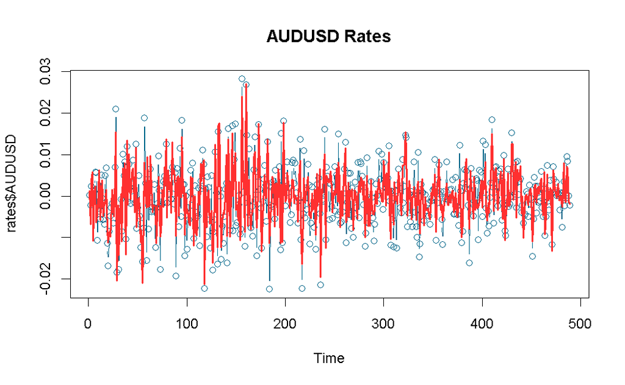

```r
regr <-  lm(AUDUSD ~  CHFUSD + GC + PL + SPX + USDNOK - 1, data=rates)
plot(rates$AUDUSD,type = "b",col='deepskyblue4',xlab='Time',main='AUDUSD Rates')
lines(regr$fitted.values,col='firebrick1',lwd=2)
```

## Анализ остатков

Посмотрим на график нормированных остатков.

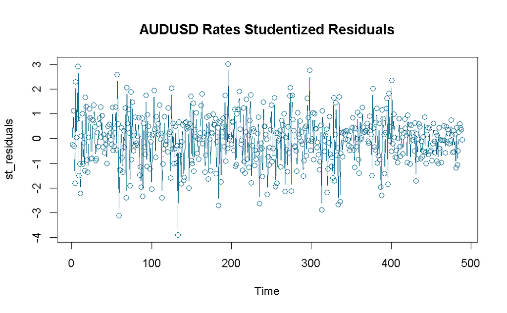

```r
st_residuals <- rstudent(regr)
plot(st_residuals, type = "b", col='deepskyblue4', xlab='Time',main='AUDUSD Rates Studentized Residuals')
```

### Проверка на некоррелированность

Проверим гипотезу о независимости остатков с помощью автокорреляционной функции.

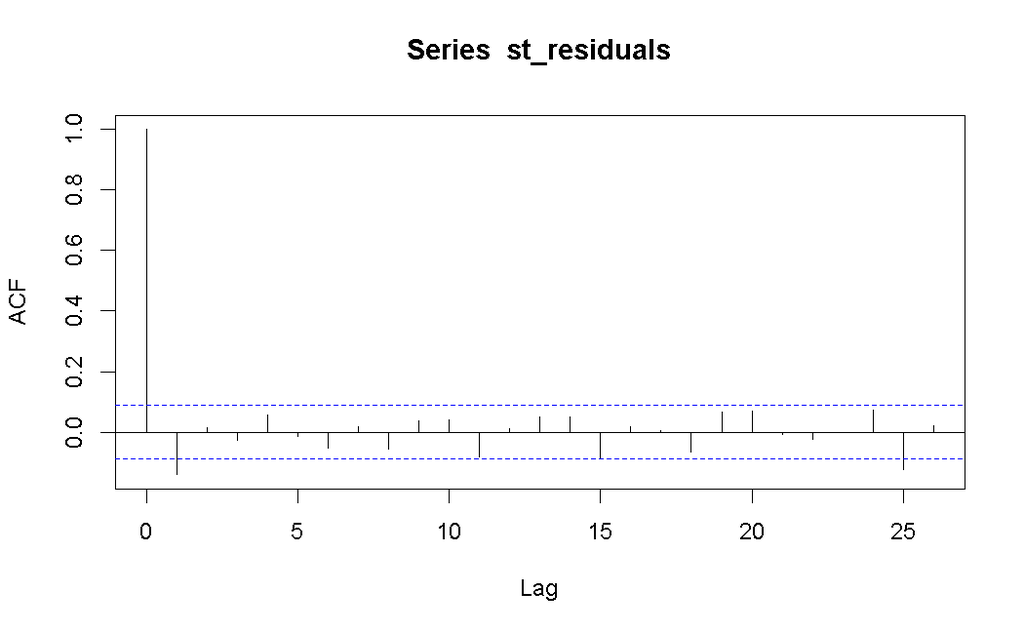

```r
acf(st_residuals)
```

В большинстве своем автокорреляции не выходят за границы полосы, однако в районе 0 наблюдается значительный скачок. Это не дает подтвердить гипотезу о независимости остатков.

### Исследование распределения

Посмотрим на график распределения остатков.

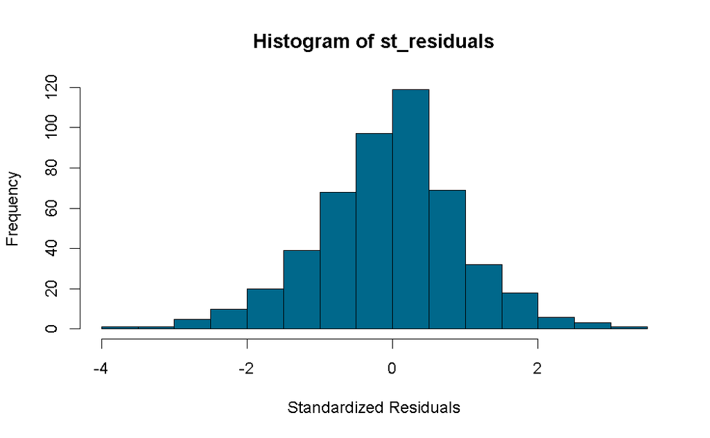

```r
hist(st_residuals, xlab='Standardized Residuals', col='deepskyblue4')
```

Исходя из формы графика можно сделать предположение о нормальном распределении. Проверим его с помощью теста Шапиро-Уилка.

```r
shapiro.test(st_residuals)
```

```
    Shapiro-Wilk normality test

data:  st_residuals
W = 0.99171, p-value = 0.007903
```

К сожалению, предположение не подтвердилось.

Воспользуемся функцией `fit.cont` из пакета `rriskDistributions`, чтобы получить другие предположения о характере распределения.

```r
fit.cont(data2fit = st_residuals)
```

```
Begin fitting distributions ---------------------------------------
* fitting normal distribution ... OK
* fitting Cauchy  distribution ... OK
* fitting logistic distribution ... OK
* fitting beta distribution ... failed
* fitting exponential distribution ... failed
* fitting chi-square distribution ... failed
* fitting uniform distribution ... OK
* fitting gamma distribution ... failed
* fitting lognormal distribution ... failed
* fitting Weibull distribution ... failed
* fitting F-distribution ... failed
* fitting Student's t-distribution ... OK
* fitting Gompertz distribution ... failed
* fitting triangular distribution ... failed
End fitting distributions -----------------------------------------
```

|  | logL | AIC | BIC | Chisq(value) | Chisq(p) | AD(value) | H(AD) | KS(value) | H(KS) |
| --- | --- | --- | --- | --- | --- | --- | --- | --- | --- |
| Normal | -694.84 | 1393.68 | 1402.06 | 32.09 | 0.01 | 1.38 | rejected | 0.05 | not rejected |
| Cauchy | -755.94 | 1515.89 | 1524.27 | 76.90 | 0.00 | 5.62 | rejected | 0.07 | rejected |
| Logistic | -690.74 | 1385.48 | 1393.86 | 22.82 | 0.16 | 0.59 | not rejected | 0.03 | not rejected |
| Uniform | NULL | NULL | NULL | Inf | 0.00 | Inf | NULL | 0.09 | rejected |
| Student | -695.11 | 1392.22 | 1396.41 | 32.83 | 0.02 | 1.48 | NULL | 0.05 | not rejected |

```
Chosen continuous distribution is: Logistic (logis)
Fitted parameters are:
   location       scale
-0.02211547  0.55601193
```

Из предложенных правдоподобнее всего выглядит гипотеза о логистическом распределении. Проверим ее с помощью теста Колмогорова-Смирнова.

```r
fitting_normal<-fitdistr(st_residuals,"logistic")
ks.test(st_residuals,'plogis',fitting_normal$estimate[1],fitting_normal$estimate[2])
```

```
    Asymptotic one-sample Kolmogorov-Smirnov test

data:  st_residuals
D = 0.032001, p-value = 0.6985
alternative hypothesis: two-sided
```

Гипотеза о логистическом распределении остатков не отвергается.